# 懒人的胡言乱语

Posted on 2021-03-01

#### 这里依旧是需要进行的很重要的库的引用

#### We need tensorflow matplotlib and pandas . If we want visual observate our train process ,TensorBoard is also a good choice.

```python
import tensorflow as tf
import matplotlib.pyplot as plt
import numpy as np
import pandas as pd
import seaborn as sns
from tensorflow import keras
from tensorflow.keras import layers, models
from tensorflow.keras.callbacks import TensorBoard
import time , os
```

#### 我们需要进行使用的数据内容

#### Map the relationship between Tv and sales

```python
tb = pd.read_csv("Advertising.csv",index_col=0)
```

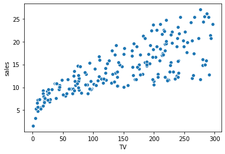

```python
# seaborn 画一下两个数据之间的对应关系
# Draw data relationship.
sns.scatterplot(tb.TV,tb.sales)
```

```python
# Init tensorflow TensorBoard log file name and location
model_name = "linerRegressiob-{}".format(int(time.time()))
current_path = os.path.join(os.getcwd(),'{}'.format(model_name))
print(current_path)
tensorboard = TensorBoard(log_dir=current_path)
```

```
/Users/change/Documents/Hexo/Blogs/source/_posts/jupyter-demo/linerRegressiob-1584289858
```

#### Example:

#### model.add(Dense(32, input_shape=(16,)))

#### now the model will take as input arrays of shape (*, 16)

#### and output arrays of shape (*, 32)

##### https://www.tensorflow.org/api_docs/python/tf/keras/layers/Dense

```python
# tf 2.0 使用keras 高阶api 的用法   创建模型
model = models.Sequential()
# 比如 y = a* w + b    y是我的预测值， y应该有很多 [y1,y2,y3,y4............]    --> < * , 1>  所以 layer.Dense(1 , xxxxx )
#  我们的输入值是已知的 [x1,x2,x3,x4 ............. ] ------->   < * , 1>  所以 input_shape = (1,)

layer1 = layers.Dense(1, input_shape=(1,))
model.add(layer1)
model.summary()
```

```
Model: "sequential"
_________________________________________________________________
Layer (type)                 Output Shape              Param #
=================================================================
dense (Dense)                (None, 1)                 2
=================================================================
Total params: 2
Trainable params: 2
Non-trainable params: 0
_________________________________________________________________
```

```python
#  建立好的模型就要进行编译 ，需要携带的参数包括正常的  optimizer , 定义损失函数 ，   metrics=['accuracy']  这块先按照默认值写吧 ， 衡量标准
model.compile(optimizer='adam',
              loss="mse",
              metrics=['accuracy']
             )
```

```python
# 上一个帖子用 低阶API 写线性回归的时候 需要自己写 for 之类的  ，这里他们提供了 epochs 可以理解为 轮次    ，前两个值就是依次喂进去变量 ， 第一个已知的 x 和 已知的 y ，
# x , y 是具有对应关系的   这个对应关系就是我们 model 里面所需要呈现的内容。
# callbacks list of callback functions .  We just want have training logs, so the list only has one value.
# callbacks 可以认为是每次运行时候的回调， api 里面要求的是list ，所以，只有一个callback 我们就只能这样写。
model.fit(tb.TV,tb.sales,epochs=1000,callbacks = [tensorboard],verbose=0)  #verbose=0 只为关掉log 想要查看 loss 变化 这个值可以设置为1
```

```
WARNING:tensorflow:Falling back from v2 loop because of error: Failed to find data adapter that can handle input: <class 'pandas.core.series.Series'>, <class 'NoneType'>
```

```
<tensorflow.python.keras.callbacks.History at 0x1a48396450>
```

```python
# 因为只有一层  而且只有两个变量， 那么我们打印一下值看一下
for value in layer1.trainable_variables:
    print(value.numpy)
```

```
<bound method BaseResourceVariable.numpy of <tf.Variable 'dense/kernel:0' shape=(1, 1) dtype=float32, numpy=array([[0.07406061]], dtype=float32)>>
<bound method BaseResourceVariable.numpy of <tf.Variable 'dense/bias:0' shape=(1,) dtype=float32, numpy=array([1.7383946], dtype=float32)>>
```

似乎 跟上一次测试的结果的两个变量的值有不太一样的部分，但是这些变量似乎不是我们最关心的部分，我们关心的值是这个 loss 值是否跟真实的很是接近。 然后我们会把模型存下来，再次塞入需要测试的数据，来进行预测。 （我对tf1.x 不太熟悉 ， 在 tf2.x 里面也只是刚刚会用，如果又要考虑变量，也得考虑结果，似乎就非常麻烦，tf2.x 使用了 Keras 的 API 使用比较高的api 就能过让我这样的小白少关心一些自己不太感兴趣的部分，会略微容易接受）

```python
# 训练以后拿到模型 ，然后取出预测值
predit_values = model.predict(tb.TV)
predit_values.shape
```

```
WARNING:tensorflow:Falling back from v2 loop because of error: Failed to find data adapter that can handle input: <class 'pandas.core.series.Series'>, <class 'NoneType'>
```

```
(200, 1)
```

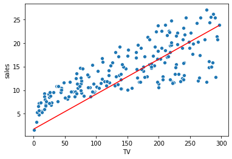

```python
# 拿到了预测值之后 画图
# Draw red Line !s
sns.scatterplot(tb.TV,tb.sales)
sns.lineplot(tb.TV,predit_values[:,0],color='red')
```

#### 高阶API 在使用的时候就会更加容易理解，省去了之前的特别难以理解的一些内容。可以吧上面的作为一种用来神经网络训练的一个模式。

#### 后面的大多数内容是在堆加网络层和如何考虑优化部分。

#### 下面一篇我打算开始写 TensorFlow 中的 Hello World 。 0 ~ 9 手写图片分类问题。

#### 这同时也是我自己的一些理解，有可能错误，如果发现有不正确的部分，麻烦及时联系我，多谢~

#### Thanks for watching ~

[figure not shown]

change

[GitHub](https://github.com/waitingchange) E-Mail